# Homework 1

ELİFNUR DUMAN 20080480

**Question 1** With Markdown write a sentence that has one word in bold.

A person arrives at every **destination**, it is enough to look, want, believe and love.

**Question 2** With Markdown write a sentence that has one word in italic.

When the prices of most goods and services are *rising* over time, the economy is said to be experiencing inflation.

**Question 3** With Markdown write a sentence that has one word in italic bold.

*Interdependence* in world affairs, as it does in private life, involves mutual dependence and cooperation.

**Question 4** With Markdown write an unordered list with three items.

Topics covered by Macroeconomics:  
*Unemployment  
*Inflation  
*Total production and consumption

**Question 5** With Markdown write an ordered list with three items.

Topics covered by Microeconomics:  
1.Consumer behavior  
2.Individual labor markets  
3.Theory of firms

**Question 6** With Markdown give a link to your favorite webpage.

This is my favorite [webpage.](https://www.mahfiegilmez.com/)

**Question 7** With Markdown add a cat picture.

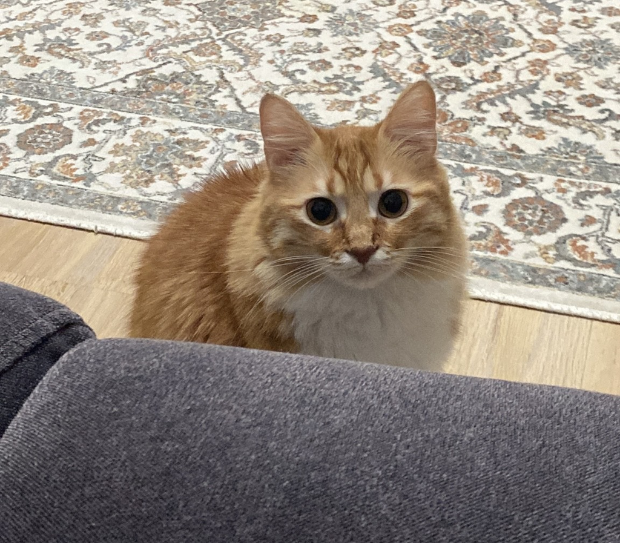

**Question 8** With Rmarkdown insert a code chunk and give an example of a simple mathematical calculation in it.

```r
pi+2^3
```

```
## [1] 11.14159
```

**Question 9** With $LaTeX$ write your favorite equation in block form.

$$(a_1+a_2)^2=a_1^2+2a_1a_2+a_2^2$$
**Question 10** In a code chunk calculate 3 + 4.

```r
3+4
```

```
## [1] 7
```